# Go to Empirical null hypothesis

```python
import os, sys
path_libraries = os.path.abspath('../libraries/')
sys.path.append(path_libraries)

from predictions_Logo_library import *
# import libraries
data = initialize_notebook_and_load_datasets()
# generate indices to split data
_train, _test, _valid = generate_split_index(data)
```

```
if ss_psipred_set is not found in globals from notebook, it will use ['E', 'H', '-']
```

```python
import itertools

# list all "k"-mers that exist in the sequence "seq"
def kmerize(seq, k):
    return ' '.join(seq[i:i+k] for i in range(len(seq) -k +1))

# generate all possible k-mers from "aa" list
def kmers(k):
    return [''.join(kmers) for kmers in itertools.product(aa, repeat=k)]

# generate one column for each of all possible kmers in data (k=2 here)
for kmer in kmers(2):
    data[kmer] = [kmerize(seq, 2).count(kmer) / 29. for seq  in data.index]
```

```python
from sklearn.linear_model import LogisticRegressionCV
from sklearn.metrics import roc_auc_score, auc, roc_curve, make_scorer

# generate combination of 2mers
_2mers = [''.join(i) for i in itertools.product(aa,aa)]

# define train,test,valid data
Xtrain, ytrain = data.loc[_train, _2mers].values, data.loc[_train, 'TAD'].values
Xtest, ytest = data.loc[_test, _2mers].values, data.loc[_test, 'TAD'].values
Xvalid, yvalid = data.loc[_valid, _2mers].values, data.loc[_valid, 'TAD'].values

# compute the model (default "l2")
model = LogisticRegressionCV(Cs = np.linspace(1e-4, 1e4, 60), scoring = make_scorer(roc_auc_score)).fit(Xtrain, ytrain)
```

```python
# initialize the 2D weights matrix
weights = np.zeros(shape=(len(aa), len(aa)))

# get coefficients of model
coefs = model.coef_[0]
coefs = (coefs - np.min(coefs)) / (np.max(coefs) - np.min(coefs))

#
for position, value in zip([i for i in itertools.product(aa,repeat=2)], coefs):
    x,y = aa.index(position[0]), aa.index(position[1])
    weights[x][y] = value


roc_auc_score(yvalid, model.predict_proba(Xvalid)[:,1])
```

```
0.9731101848347468
```

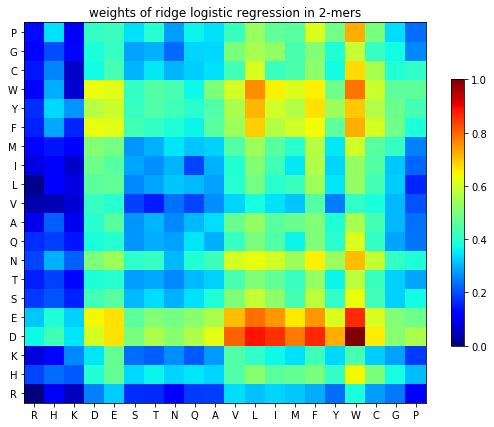

```python
f, ax = plt.subplots(1, figsize=(9,7))
im = ax.pcolor(weights, cmap='jet')
ax.set_xticks(np.arange(20)+0.5)
ax.set_yticks(np.arange(20)+0.5)
ax.set_xticklabels(aa)
ax.set_yticklabels(aa);
plt.colorbar(im, shrink=0.7)
plt.title('weights of ridge logistic regression in 2-mers');
#plt.savefig('weights_of_ridge_logistic_regression_in_2_mers.jpg', dpi=1200)
```

```python
# try using 10 to 100% of the data and see if performance and weigths change much

# In weights all sub-weights will be stored, in rocs, roc_auc values will be stored
weights = []
rocs = []

for fraction in np.linspace(0.1,1,10):

    # get subsample
    subsamples = int(fraction * Xtrain.shape[0])
    Xsubtrain, ysubtrain = Xtrain[:subsamples], ytrain[:subsamples]

    #train the model
    model = LogisticRegressionCV(Cs=np.linspace(1e-4, 1e4, 60), scoring = make_scorer(roc_auc_score)).fit(Xsubtrain, ysubtrain)

    # compute a weights matrix
    sub_weights = np.zeros(shape=(len(aa), len(aa)))

    # get coefficients of model
    coefs = model.coef_[0]
    coefs = (coefs - np.min(coefs)) / (np.max(coefs) - np.min(coefs))

    # fill the sub_weights matirs and append to weights
    for position, value in zip([i for i in itertools.product(aa,repeat=2)], coefs):
        x,y = aa.index(position[0]), aa.index(position[1])
        sub_weights[x][y] = value
    weights.append(sub_weights)

    rocs.append(roc_auc_score(yvalid, model.predict_proba(Xvalid)[:,1]))
```

```
Text(0,0.5,'performance')
```

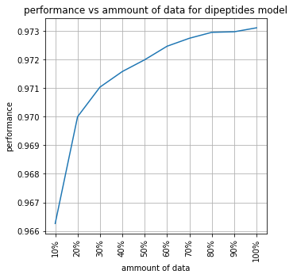

```python
f,ax = plt.subplots(figsize=(5,5))
plt.title("performance vs ammount of data for dipeptides model")
ax.plot(rocs)
ax.grid()
ax.set_xticks(np.arange(10))
ax.set_xticklabels([str(i)+'%' for i in np.arange(10,101,10)], rotation=90)
ax.set_xlabel('ammount of data')
ax.set_ylabel('performance')
```

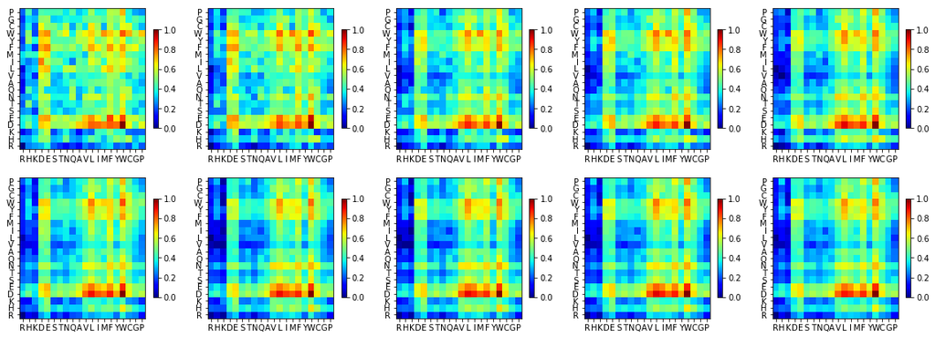

```python
plt.figure(figsize=(20,7))
for n,i in enumerate(weights):
    ax = plt.subplot(2,5,n+1)
    im = ax.pcolor(i, cmap='jet')
    ax.set_xticks(np.arange(20)+0.5)
    ax.set_yticks(np.arange(20)+0.5)
    ax.set_xticklabels(aa)
    ax.set_yticklabels(aa);
    plt.colorbar(im, shrink=0.7)
    #plt.title('weights of ridge logistic regression in 2-mers');
```

```python
# Make frames for a short gif showing performance of 2mer model and heatmap.
from matplotlib import gridspec

for n,w in enumerate(weights):

    # create figure
    plt.figure(figsize=(5,6))
    gs = gridspec.GridSpec(2, 1, height_ratios=[1, 6])

    # plot y_axis=score and x_axis=subsmple%
    ax0 = plt.subplot(gs[0])
    ax0.plot(np.arange(1,n+1), np.array(rocs)[:n])
    ax0.set_xlim(0,10)
    ax0.set_ylim(0.966, 0.975)
    ax0.grid()
    ax0.set_title('performance of ridge logistic regression vs 2mers distance')

    # plot the heatmap of 2mers combined
    ax1 = plt.subplot(gs[1])
    im = ax1.pcolor(w, cmap='jet')
    ax1.set_xticks(np.arange(20)+0.5)
    ax1.set_yticks(np.arange(20)+0.5)
    ax1.set_xticklabels(aa)
    ax1.set_yticklabels(aa)
    ax1.set_title('heatmap 2mers coefficients in the logistic model')

    #plt.tight_layout()

    plt.savefig('heatmap_'+str(n+1)+'.jpg', dpi=300)
    plt.close()
```

# Predictions on yeast activators

```python
from predictions_library import *
```

```python
# prepare dfs. IMPORTANT: these "properties.fasta" contain MUCH more sequences than positive+negative.
# Reduce it to the index that will be used and discard ALL sequences that are not going to be used.
reduced_index, labels = data.index, data.TAD

# load and get ohe matrices of all secondary structures and disorder
ss_psipred = load_predicted_properties(myHOME+ '/data/30mers_ALL.PSIPRED_ss.fasta')
#ss_psipred_set = list(set(np.concatenate([i for i in ss_psipred.values]))) ------>>> I have defined this in the first cell!!

# One hot encode all categorical variables
def ohe_wrap(data, categories): return np.array([ohe(data.loc[i], categories) for i in reduced_index])
ss_psipred = ohe_wrap(ss_psipred, ss_psipred_set)

# combine all variables together, categorical and numerical
sequences = np.array([ohe(seq, aa) for seq in reduced_index])
ohe_data = np.vstack([sequences.T, ss_psipred.T]).T
```

```
/fh/scratch/delete90/hahn_s/aerijman/11_12_2018/TADs-analysis/empirical_null_model/data/30mers_ALL.PSIPRED_ss.fasta loaded succesfully!
```

```python
import keras.backend as K
from keras.layers import Dense, Conv2D, Flatten, AveragePooling2D, Input, Dropout
from keras.models import Model
from keras.callbacks import EarlyStopping
from keras.activations import softplus, softsign


# Split data 8:1:1
idx = np.arange(ohe_data.shape[0])
np.random.seed=0
np.random.shuffle(idx)
_8, _9 = int(ohe_data.shape[0]*0.8), int(ohe_data.shape[0]*0.9)
train, test, valid = idx[:_8], idx[_8:_9], idx[_9:]

shape = ohe_data.shape
ohe_data = ohe_data.reshape(tuple(list(shape)+[1]))

# define the sets with ALWAYS same split
Xtrain, Xtest, Xvalid = [ohe_data[i] for i in [train, test, valid]]
ytrain, ytest, yvalid = [labels[i] for i in [train, test, valid]]



# Due to technical reasons, optimization of the model was done with a sbatch command.
from keras.models import model_from_json

K.clear_session()
inputs = Input(shape=(30,Xtrain.shape[2],1))
x = Conv2D(29, (4,Xtrain.shape[2]), activation=softplus)(inputs)
x = Flatten()(x)
x = Dense(300, activation=softplus)(x)
x = Dropout(0.3)(x)
x = Dense(30, activation=softplus)(x)
output = Dense(1, activation='sigmoid')(x)
deep_model = Model(inputs=inputs, outputs=output)

# before compiling the model, load the winner weights
deep_model.load_weights(myHOME + '/models/winner_weights.h5')

# compile with winner weights
deep_model.compile(optimizer='adam', loss='binary_crossentropy', metrics=['accuracy'])

roc_auc_score(yvalid, deep_model.predict(Xvalid))
```

```
0.9786224715784319
```

# Look for extreme samples in charges vs predictions

```python
# reduced_index
# ohe_data
# labels
# predictions
#charges
predictions = [deep_model.predict(i.reshape(np.append(1,i.shape)))[0][0] for i in ohe_data]
charges = [calculate_charge(i) for i in reduced_index]
```

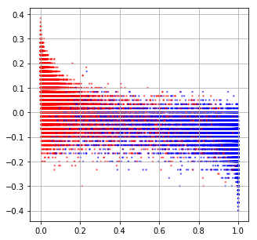

```python
plt.figure(figsize=(5,5))
cols = ['r' if i==0 else 'b' for i in labels ]
plt.scatter(predictions, charges, s=2, alpha=0.5, c=cols)
plt.grid()
```

```python
df_weirds = np.vstack([charges, predictions, list(labels)])
df_weirds = pd.DataFrame(df_weirds.T, index=list(reduced_index), columns = ['charges','predictions','labels'])
```

```python
#df_weirds[(df_weirds.charges<-0.25) & (df_weirds.labels==0) & (df_weirds.predictions>0.6)]
# Apply MEME motif discovery to find any significant motif in these sequences.
import uuid
for i in df_weirds[(df_weirds.charges<-0.25) & (df_weirds.labels==0) & (df_weirds.predictions>0.6)].index:
    print('>' + str(uuid.uuid4()) + '\n' + i)
```

```
>89dc2b73-f7b0-4e67-9278-1a69101365c4
EEDALVGIVDYEMKLKFGEERNEEEVLEAE
>5dabec47-f5ca-429c-bc07-8822d0def21f
ETTDDECVEEVIVCDVYLDENCDTQTGLGK
>adc9964f-84d3-4b3e-a49b-1261db59e106
VVVTEDIAGEEEDFMGSDEYGEKEYDCVGL
>1baffee7-96c0-4a76-a70a-a450f5dd19ee
YDVGDFDYTCVHDEQAVIEEVDKPDEGVVN
>85fcf2d6-2dc0-4172-85a9-2fbf0f215f3c
CEDDDSNEEEITTELLIAYAVGKAWFEVCL
>0e35b26c-32e5-4f6d-9cef-a27b7e1a923e
KLTEEDVGGEDEVVEQIDWAFCIESKDIDG
>784678d5-d7a1-43de-b60c-2326619fb2ed
SVVCDVDISDEHECCDGGIDDFVQMYASEY
>bd079893-6a8c-41e5-9601-177152ce9525
FAESIDVGDFGMERIVENEESVMGVDVEDG
>16650303-c839-4a5a-b481-9897bf2a2cdd
SIQTASTEVDSDEENDLVGAECTTVDCSCF
>6b3e55ee-2d97-47b6-abfc-233700b0bea1
MDSNETIMDFQSGLDTESLEQTSWDGPDGQ
>c62a8324-13ef-4834-a51f-8638cf458b7f
FTEGVCCQLLRVADYDGENDNVDIVVDDFD
>00a5daa1-07c7-4ae9-87a0-5464c7a78ce5
NDEDPVVYLVESDEWNIVLDGSDSVNDDEI
>8f2f68eb-341a-4f4c-85a3-c4ea141f5949
VEFNVYVTIDVDEETSVEEEFFMNLCAATW
>c7b36f3e-1635-4800-aad6-3dc43f7681c8
LINGDVVVVVGVEDEGVEAEDFDEVATLYA
```

```python
for i in df_weirds[(df_weirds.charges>0.15) & (df_weirds.labels==1) & (df_weirds.predictions<0.2)].index:
    print('>' + str(uuid.uuid4()) + '\n' + i)
```

```
>ac9c5817-b052-40a2-ab43-9d0dbcc1ce5e
IIKTGVFTGLRQNSRGSRVGRVPRGFGPGG
>46557579-0e14-4a8e-b8ec-6a6143261478
IVIVIASAAVCGNVVKYSKGKKWDYKKMIA
>a02e1ce8-8b71-4b57-aa0d-2f8162b0a5dc
FGTVAPMNVFLWHRRCLHGGRHNRGLYSLI
>5a3e73de-85e5-4a3e-b264-9dba6435e1cf
RGLCLRGRPYAVWPRHIGKVFWSSSSTVSP
>a76ed06d-b78c-45f9-b606-308b43cc8054
SYSFGTLGCTGVKKHASSGMVKRIHRGTAM
>5483b686-0c3c-438f-bea3-bde04a311e7a
ACLNLWCQKVGNRLTRVCPYIAQINVRKSS
>43c29841-06f6-40fc-8603-ab427ff7e5f3
FWDEPRHQCGSRMILRRKSTTGFGLRPGLR
>e4da4542-c6fe-4614-b611-9802f0571e2f
YTIFRYSRHCGRPHGQALAPGPSTHVTFRK
>b3dc5650-c133-49f8-b222-b4edb8c46dda
GGMFWLGRSSRQVIPTKVRRRHNLDVGSAM
>62051d35-0cfa-4df6-bff4-a890bfe0a3ac
NTYGFCIIMRRVKCAKYIVYTNINKVRDIY
>b84117d0-32aa-4c40-9ce2-9db844770277
CLRRASWSLCTRSFTNSRWSVGKYTSGPVS
>6ccf490d-60eb-458a-84b8-60bf5794f097
SRVETCHCYPRLHNNRCVSRFLQWHRPRGS
>534d3894-2b06-48a4-aeed-942fd706da17
RGMSNCVSPRRSAKACKYTSRVWLYMDYFG
>95661cb2-9ec4-4821-b49a-17a5b26b6626
MVAHGRIGFPNHRLRGARPFLVTTRKAATW
>4da31728-4d18-4096-9808-3b09b4032f6c
QKVSEERVKKKRTSNICQVLGTTMKQVFVV
>16615735-b200-408e-8f0d-516a07f36c31
GARRREKKAGSLDVEVRKWRNVLAMWTHVG
>cf7c5a22-6cb8-466b-9440-e6e195bbc3d8
LKNTWAKSVIPGPYCFLYNNSRNHNLAHRS
```

### couldn't find any significant motif or patter on neither these sets of sequences

# Predicting values of natural activators and saturated mutagenesis

```python
# gcn4
gcn4_sequence = myHOME + '/data/gcn4.fasta'
gcn4_ss = myHOME + '/data/gcn4.horiz'

# met4
met4_sequence = myHOME + '/data/met4.fasta'
met4_ss = myHOME + '/data/met4.horiz'

# ino2
ino2_sequence = myHOME + '/data/ino2.fasta'
ino2_ss = myHOME + 'data/ino2.horiz'

# gal4
gal4_sequence = myHOME + '/data/gal4.fasta'
gal4_ss = myHOME + '/data/gal4.horiz'

# mtf1
mtf1_sequence = myHOME + '/data/mtf1_fly.fasta'
mtf1_ss = myHOME + '/data/mtf1_fly.horiz'
```

```python
seq = open_fasta(gcn4_sequence)
ss = open_ss(gcn4_ss)
ohe_gcn4 = ohe_single(seq,ss, aa_list=aa, ss_list=ss_psipred_set)

predictions = []
for i in range(0, len(ss)-30):
    region = deep_model.predict(ohe_gcn4[0, i:i+30, :, 0].reshape(1,30,23,1))[0][0]
    predictions.append(region)
```

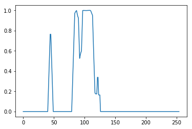

```python
plt.plot(np.convolve([i if i>=0.8 else 0 for i in predictions], np.ones(5)/5))
```

### LEFT FOR LATER:

# Print sequencing profiles of Stark sequences.

```python
Stark_data_genome = open_fasta(myHOME + '/data/Stark_tADs/GSE114387_TFbb_list180_linear.fa')
Stark_data_annot = pd.read_csv('../data/Stark_tADs/TFtracks.bed', delimiter='\t', header=None, names=['_','start','end']+['_']*6, index_col=3).iloc[:,1:3]

'''# convert bigWig into wig to access GFP files
BP_STEP = 1 #read data from bw every x bases
from subprocess import run
run(['/home/ariel/Documents/tools/bwtool/bwtool/bwtool', 'chromgraph','-every='+str(BP_STEP),
     myHOME + '/data/Stark_tADs/short-library_GFP-_1+.bw', myHOME + '/data/Stark_tADs/short-library_GFP-_1+.wig'])
run(['/home/ariel/Documents/tools/bwtool/bwtool/bwtool', 'chromgraph','-every='+str(BP_STEP),
     myHOME + '/data/Stark_tADs/short-library_GFP+_1+.bw', myHOME + '/data/Stark_tADs/short-library_GFP+_1+.wig'])
'''
# load them into dictionaries
gfp_p = read_wig(myHOME + '/data/Stark_tADs/short-library_GFP+_1+.wig')
gfp_m = read_wig(myHOME + '/data/Stark_tADs/short-library_GFP-_1+.wig')
'''
# remove wig files from memory
run(['rm', myHOME + '/data/Stark_tADs/short-library_GFP+_1+.wig'])
run(['rm', myHOME + '/data/Stark_tADs/short-library_GFP-_1+.wig'])
'''
# prepare all fasta files to use in psipred predictions
''' for i in Stark_data_annot.index:
    filename = i + '.fasta'
    start, end = Stark_data_annot.loc[i, ['start', 'end']]
    dna_sequence = Stark_data_genome[start:end]
    protein_seq = translate_dna2aa(dna_sequence)
    f = open(filename, 'w')
    f.write('>'+i+'\n'+protein_seq)
    f.close()''';
```

```
done! /fh/scratch/delete90/hahn_s/aerijman/11_12_2018/TADs-analysis/empirical_null_model/data/Stark_tADs/short-library_GFP+_1+.wig file loaded
done! /fh/scratch/delete90/hahn_s/aerijman/11_12_2018/TADs-analysis/empirical_null_model/data/Stark_tADs/short-library_GFP-_1+.wig file loaded
```

[output not shown]

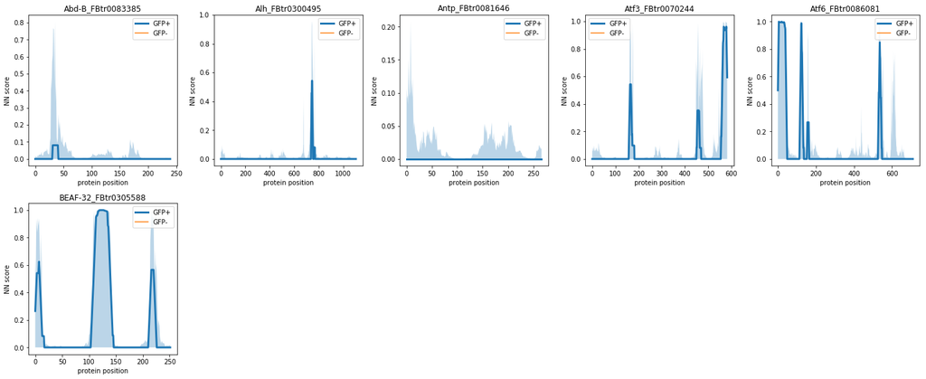

```python
for sample in np.arange(0,181,30):
    plt.figure(figsize=(20,24))
    for n, TF_name in enumerate(Stark_data_annot.index[sample:sample+30]):

        # if ss file is not here yet, skip
        if not os.path.exists('../data/Stark_tADs/horiz/'+ TF_name + '.horiz'): continue

        # open fasta and horiz files and generate ohe
        seq = open_fasta('../data/Stark_tADs/fastas/'+ TF_name + '.fasta')
        ss = open_ss('../data/Stark_tADs/horiz/'+ TF_name + '.horiz')
        single = ohe_single(seq,ss, aa_list=aa, ss_list=ss_psipred_set)

        # predict using deep_model
        predictions = []
        for i in range(0, len(ss)-30):
            region = deep_model.predict(single[0, i:i+30, :, 0].reshape(1,30,23,1))[0][0]
            predictions.append(region)

        #plot predictions
        plt.subplot(6,5,n+1)
        plt.fill_between(range(len(predictions)), predictions, alpha=0.3)
        plt.plot(np.convolve([i if i>=0.8 else 0 for i in predictions], np.ones(10)/10, "same"), lw=3)
        plt.xlabel('protein position')
        plt.ylabel('NN score');


        # plot gfp+ and gfp-
        start, end = Stark_data_annot.loc[TF_name, ['start','end']]
        plus = gfp_p.iloc[start:end].counts.values
        minus = gfp_m.iloc[start:end].counts.values
        # make plus and minus averaged every 3 nt to plot together with protein
        plus = np.array([np.mean(plus[i:i+3]) for i in np.arange(0, len(plus), 3)])
        minus = np.array([np.mean(minus[i:i+3]) for i in np.arange(0, len(minus), 3)])

        # take values of tADs whose plus/minus >2 and plus >100 counts
        tAD = plus/minus
        tAD = np.array([k if k>2 and i>100 else 0 for i,k in zip(plus, tAD)])
        tAD = (tAD - np.min(tAD)) / (np.max(tAD) - np.min(tAD))

        plt.plot(tAD)
        #plt.plot(plus)
        #plt.plot(minus)
        plt.legend(['GFP+', 'GFP-'])
        plt.title(TF_name)
        plt.tight_layout()
    #plt.savefig('predictions_Stark_' + str(sample) + '-' + str(sample+30) + '.jpg')
```

# Empirical permutation null hypothesis

$i$: position index  
$f$: factor index

$\vec{prediction}: p{\lbrack}f{\rbrack\lbrack}i{\rbrack}$  
$\vec{measurement}: m{\lbrack}f{\rbrack\lbrack}i{\rbrack}$

Algorithm:

- Draw permutation of $\{1..f\}p_{i}{\lbrack}f{\rbrack}$
- Concatenate (unroll) all $p{\lbrack} p_{i}{\lbrack}f{\rbrack} {\rbrack}{\lbrack}i{\rbrack}$
- Concatenate (unroll) all $m{\lbrack}f{\rbrack}{\lbrack}i{\rbrack}$
- Compute correlation between unrolled $m{\lbrack}f{\rbrack}{\lbrack}i{\rbrack}$ and $pi{\lbrack}f{\rbrack} {\rbrack}{\lbrack}i{\rbrack}$  
  pearson --> $corr(m,p)=(1/N)\sum_{j} \frac{(m_{j} - \bar{m}) * (p_{j} - \bar{p})} {(\sigma_{p}*\sigma_{m})}$

Then either measure the proportion of the area under the curve from that point (correlation of the original p vector, without permutation) to its right or left (for positive or negative value)

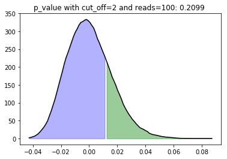

```python
Stark_data_annot = Stark_data_annot.drop('Su(var)2-10_FBtr0088576', axis=0)

# original factor and position indexes
f = list(Stark_data_annot.index)  ####################################################################--> I should ONLY use genes that show enrichment over the background

# generate tables of measurements and predictions for genes in Stark data
m_dict = make_m_dict(Stark_data_annot, gfp_p, gfp_m)
p_dict = make_p_dict(Stark_data_annot, deep_model)

# join values into vectors for measurements and predictions.
m = np.concatenate([m_dict[i][:-30] for i in f]) # [:-30] because I didn't predict score for these residues
p = np.concatenate([p_dict[i] for i in f])


# compute original correlation
corr = np.corrcoef(m,p)[0][1]

### Assuming that p value is the probability of type-I error, this area should be the equivalent
corr_distrib = build_distribution(f,p_dict,m)

p_value = calc_typeI_error(corr_distrib, corr, plot=True, bins=100)
plt.title("p_value with cut_off=2 and reads=100: {} ".format(p_value));
```

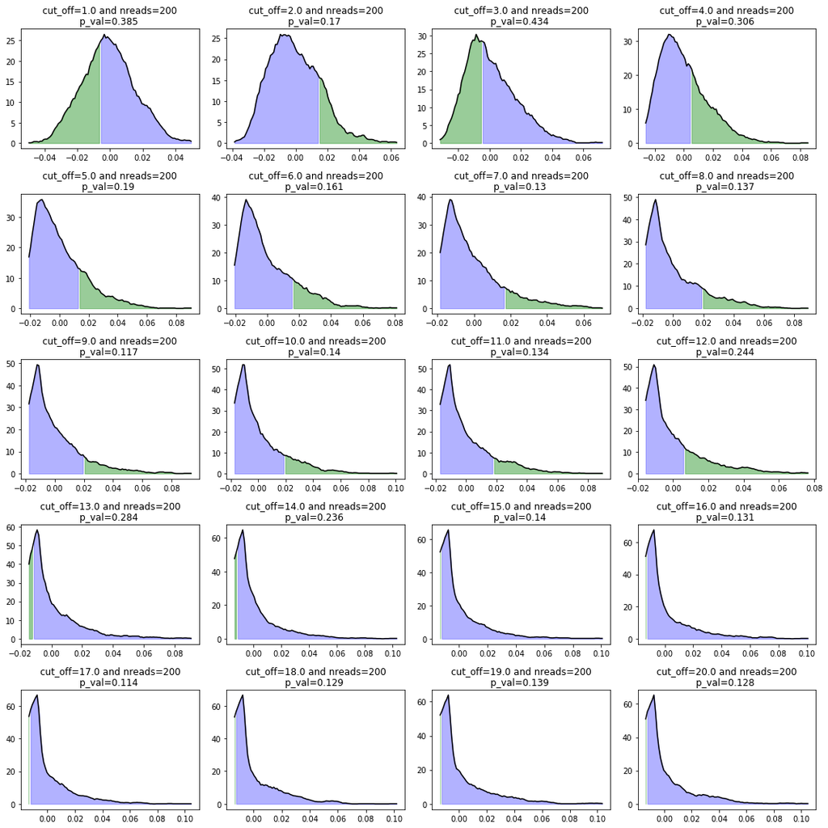

```python
plt.figure(figsize=(15,15))

MINIMUM_READS = 200
cutoffs = np.linspace(1,20,20)
p_values = []

for n,FOLD_CHANGE_THRESHOLD in enumerate(cutoffs):

    # generate tables of measurements and predictions for genes in Stark data
    m_dict = make_m_dict(Stark_data_annot, gfp_p, gfp_m, MINIMUM_READS=MINIMUM_READS, FOLD_CHANGE_THRESHOLD=FOLD_CHANGE_THRESHOLD)
    p_dict = make_p_dict(Stark_data_annot, deep_model)

    # join values into vectors for measurements and predictions.
    m = np.concatenate([m_dict[i][:-30] for i in f]) # [:-30] because I didn't predict score for these residues
    p = np.concatenate([p_dict[i] for i in f])


    # compute original correlation
    corr = np.corrcoef(m,p)[0][1]

    ### Assuming that p value is the probability of type-I error, this area should be the equivalent
    corr_distrib = build_distribution(f,p_dict, m, n_iter=1000)

    # make it as subplots
    plt.subplot(5,4,n+1)

    p_value = calc_typeI_error(corr_distrib, corr, plot=True, bins=100)
    plt.title("cut_off={} and nreads={}\np_val={} ".format(FOLD_CHANGE_THRESHOLD, MINIMUM_READS, p_value));
    p_values.append(p_value)

plt.tight_layout()
plt.savefig('empirical_nullH_p_values_completeSet_reads-{}-cutOffs-{}'.format(MINIMUM_READS, cutoffs)+'.jpg')
```

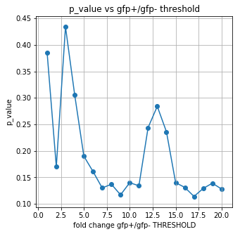

```python
plt.figure(figsize=(5,5))
plt.grid()
plt.xlabel('fold change gfp+/gfp- THRESHOLD')
plt.ylabel('p_value')
plt.plot(cutoffs, p_values)
plt.scatter(cutoffs, p_values)
plt.title('p_value vs gfp+/gfp- threshold');
plt.savefig('p_value__VS__threshold_minReads-{}-cutOffs-{}'.format(MINIMUM_READS, cutoffs)+'.jpg')
```

### If we use the subset of Stark's TF with real peaks judging by eye the p_value should be smaller and the drop might be deeper.

```python
# A: plot TFs with a region (longer than three amino-acids) with fold change=3 and reads>200.
### That region should be detected as a peak, nevertheless, most of these peaks look like a
### overamplified single sequence, since it starts and ens very sharply
# B = A, except that ther should be no peak on the gfp- where the enrichment peak is detected.

#########
### A ###
#########

# in lista I store tfs with requirements
lista = []

for tf in f:
    s,e = Stark_data_annot.loc[tf,['start','end']].values

    # signal is from gene NOT FROM PROTEIN => region should be at least 9 bp long.
    signal = np.nan_to_num([gfp_p.iloc[i].values[0] / gfp_m.iloc[i].values[0]
                            if gfp_p.iloc[i].values[0]>200 else 0 for i in range(s,e)])

    # positions where requirements are valid
    signal = np.where(signal>2)[0]
    # return True if there is region FC>2 and reads>200 else False
    if len(signal)<9:
        continue

    for position in range(9, len(signal)-18):
        if signal[position] - signal[position-9] == 9:
            lista.append(tf)
            break
```

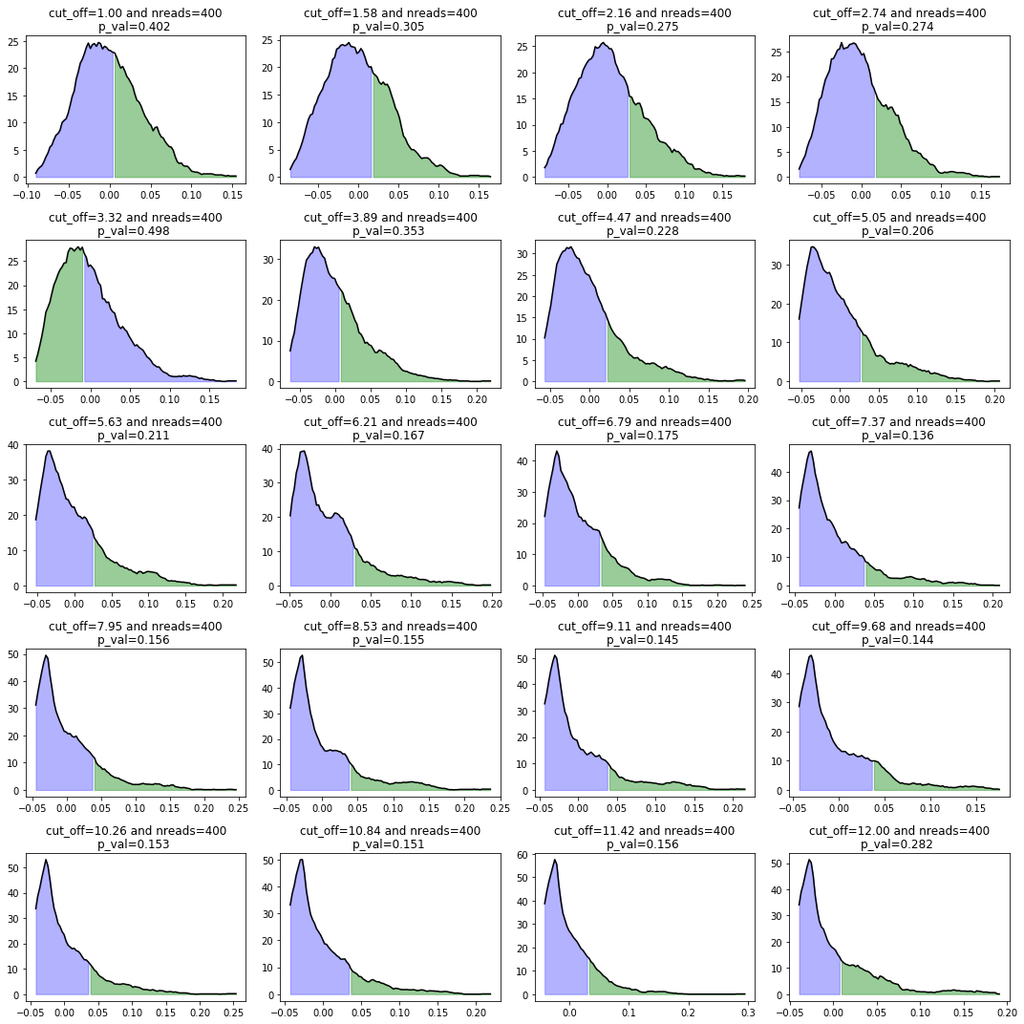

```python
plt.figure(figsize=(15,15))

MINIMUM_READS = 400
cutoffs = np.linspace(1,12,20)
p_values = []

for n,FOLD_CHANGE_THRESHOLD in enumerate(cutoffs):

    # generate tables of measurements and predictions for genes in Stark data
    m_dict = make_m_dict(Stark_data_annot.loc[lista], gfp_p, gfp_m, MINIMUM_READS=MINIMUM_READS, FOLD_CHANGE_THRESHOLD=FOLD_CHANGE_THRESHOLD)
    p_dict = make_p_dict(Stark_data_annot.loc[lista], deep_model)

    # join values into vectors for measurements and predictions.
    m = np.concatenate([m_dict[i][:-30] for i in lista]) # [:-30] because I didn't predict score for these residues
    p = np.concatenate([p_dict[i] for i in lista])


    # compute original correlation
    corr = np.corrcoef(m,p)[0][1]

    ### Assuming that p value is the probability of type-I error, this area should be the equivalent
    corr_distrib = build_distribution(lista,p_dict, m, n_iter=1000)

    # make it as subplots
    plt.subplot(5,4,n+1)

    p_value = calc_typeI_error(corr_distrib, corr, plot=True, bins=100)
    plt.title("cut_off={:.2f} and nreads={}\np_val={} ".format(FOLD_CHANGE_THRESHOLD, MINIMUM_READS, p_value));
    p_values.append(p_value)

plt.tight_layout()
plt.savefig('empirical_nullH_p_values_completeSet_reads-{}'.format(MINIMUM_READS)+'__30_TFs.jpg')
```

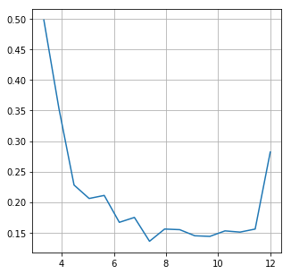

```python
plt.figure(figsize=(5,5))
plt.grid()
plt.plot(cutoffs[4:], p_values[4:])
```

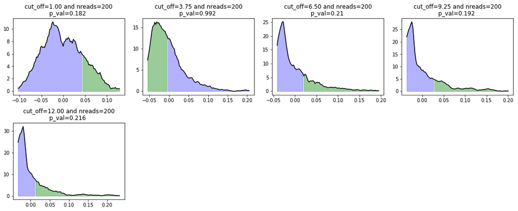

```python
def calc_typeI_error(corr_values, point, **kwargs):
    '''
        function makes distribution out of correlation values (corr_values)
        and calculate the area under "normal" curve as extreme or more extreme than point,
        that is the probability that a number falls on the right of the point in that curve(
        if point is positive, else to the left of the point).
        INPUT = corr_values (list of values of correlation) and point (single sample to test)
        optional = bins (bins=100) and plot (plot=True)
        OUTPUT = type I error or area under the curve from point to the right or
                 point to the left if point is negative value.
    '''
    # allow user to input bins number
    if 'bins' in kwargs.keys(): bins=kwargs['bins']
    else: bins=100

    # make histogram of corr_values
    y,x = np.histogram(corr_values, bins=bins)

    # have to make x.shape=y.shape
    x = x[:-1]

    # allow user to plot the distribution
    if 'plot' in kwargs.keys():
        if kwargs['plot']==True:
            yc = np.convolve(y, np.ones(10)/10, "same")
            if point>0:
                _right = np.where(x>=point)
                _left = np.where(x<point)
                plt.plot(x, yc, c="k")
                plt.fill_between(x[_right], yc[_right], color='g', alpha=0.4)
                plt.fill_between(x[_left], yc[_left], color='b', alpha=0.3)
            else:
                _left = np.where(x<=point)
                _right = np.where(x>point)
                plt.plot(x, yc, c="k")
                plt.fill_between(x[_right], yc[_right], color='b', alpha=0.3)
                plt.fill_between(x[_left], yc[_left], color='g', alpha=0.4)

    # if point is negative, flip the curve and make point positive
    if point<0:
        point = point*-1.
        y = y[::-1]

    # measure total area and area from point to it's right
    total_area = np.sum(y)
    index_point2right = np.where(x>=point)
    area_point_right = np.sum(y[index_point2right])

    # typeI error
    probaTypeI = area_point_right *1. / total_area

    return probaTypeI




plt.figure(figsize=(15,15))

MINIMUM_READS = 200
cutoffs = np.linspace(1,12,5)
for n,FOLD_CHANGE_THRESHOLD in enumerate(cutoffs):

    # generate tables of measurements and predictions for genes in Stark data
    m_dict = make_m_dict(Stark_data_annot.loc[lista], gfp_p, gfp_m, MINIMUM_READS=MINIMUM_READS, FOLD_CHANGE_THRESHOLD=FOLD_CHANGE_THRESHOLD)
    p_dict = make_p_dict(Stark_data_annot.loc[lista], deep_model)

    # join values into vectors for measurements and predictions.
    m = np.concatenate([m_dict[i][:-30] for i in lista]) # [:-30] because I didn't predict score for these residues
    p = np.concatenate([p_dict[i] for i in lista])


    # compute original correlation
    corr = np.corrcoef(m,p)[0][1]

    ### Assuming that p value is the probability of type-I error, this area should be the equivalent
    corr_distrib = build_distribution(lista,p_dict, n_iter=500)

    # make it as subplots
    plt.subplot(5,4,n+1)

    p_value = calc_typeI_error(corr_distrib, corr, plot=True, bins=100)
    plt.title("cut_off={:.2f} and nreads={}\np_val={} ".format(FOLD_CHANGE_THRESHOLD, MINIMUM_READS, p_value));

plt.tight_layout()
plt.savefig('empirical_nullH_p_values_completeSet_reads-{}'.format(MINIMUM_READS)+'__30_TFs.jpg')
```

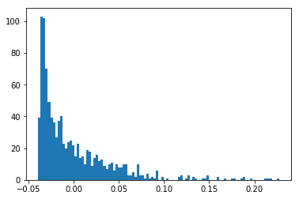

```python
plt.hist(corr_distrib, bins=100);
```

## Babu's data

```python
# sequence of the 3' region used to complete to 30aa if needed.
p3='TNARNNMSPNNDDNSIDTASTNTTNRKKNI'

# read sequence and secondary structure
f = open('../data/Babu/horiz.results')

seqs, sss = [], []
while True:
    try:
        Babu_seq, Babu_ss = next(f), next(f)

        # if sequence is too short (how could this happen if len(p3)=30?) or there is no ss, skip
        if len(Babu_seq)<31 or len(Babu_ss) != len(Babu_seq[1:]): continue

        # sequence has a > in position 0
        seqs.append(Babu_seq.strip("\n")[1:])
        sss.append(Babu_ss.strip('\n').replace("C","-"))

    except StopIteration:
        break
```

```python
k, v = [],[]
for n,i in enumerate(open('../data/Babu/inline-supplementary-material-2.csv')):
    if n==0: continue
    _, sequence, _, clas =  i.strip('\n').split(",")
    k.append(sequence)
    v.append(clas)

Babu_classes = dict(zip(k,v))
```

```python
# predictions_B has all predictions on Babu's dataset completing last residues to 30 with the p3 sequence
k,v = [],[]
for i,j in zip(seqs, sss):
    ohe_sample = ohe_single(sequence=i[-30:], ss=j[-30:], aa_list=aa, ss_list=ss_psipred_set)
    k.append(i[30:])
    v.append([Babu_classes[i[30:]], deep_model.predict(ohe_sample)[0][0]])

predictions_B = pd.DataFrame(v, index=k, columns=['label', 'predictions'])
```

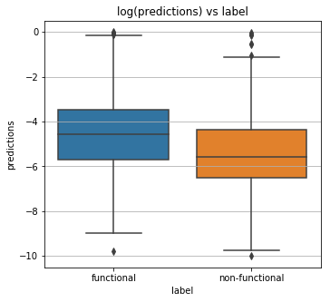

```python
import seaborn as sns
p = predictions_B.copy()
p.predictions = np.log(p.predictions)

# boxplot
plt.figure(figsize=(12,5))
plt.subplot(1,2,1)
plt.grid()
sns.boxplot(data=p, x='label', y='predictions')
plt.title('log(predictions) vs label')

# roc_curve
tp, fp, tn, fn = [],[],[],[]

#plt.subplot()
```

## Do saturated mutagenesis and Logos

```python
ohe_data.shape
```

```
(74592, 30, 23, 1)
```

```python
def calculate_probability(scores_matrix, bg, c=2):
    probs = np.log(c * scores_matrix)
    probs2 = np.zeros(shape=probs.shape)

    for position in range(scores_matrix.shape[0]):
        probs2[position,:] = probs[position,:] - np.log(bg) #np.sum(probs[position,:])

    return probs2


from subprocess import run, Popen

def make_logo(prediction, probs, ohe_sample):

    # name files with the sequence
    output = ''.join([aa[np.where(i==1)[0][0]] for i in ohe_sample[:,:20,0]])

    # save df to use in seq2logo
    pd.DataFrame(probs, columns=aa, index=[str(i)+' A' for i in np.arange(1,31)]).to_csv(output+'.csv', sep='\t')

    # run seq2logo
    script = ['python2.7','../../../../from_scratch/seq2logo-2.1/Seq2Logo.py','-f', output+'.csv','-I','1', '-o',output+'_'+str(prediction),'--format','JPEG']
    process = Popen(" ".join(script), shell=True, env={"PYTHONPATH": "."})

    print(output+ " done")
```

```python
for i in range(10):

    # get a random index number
    idx = np.random.randint(len(ohe_data)-1)

    # select sample
    sample = ohe_data[idx]

    # compute matrix of prediction scores from saturated mutagenesis
    bg, saturated = compute_mutagenesis(sample, deep_model)

    # convert results into PWM probabilities
    pwm = calculate_probability(saturated, bg)

    # make Logo
    make_logo(bg, pwm, sample)
```

```
using local aa list
SIRINRFFAPVTTGADLFTLVTTHLRLQPV done
using local aa list
ETGDTFDMFEGWLSCSKTYSPDAILAVPCF done
using local aa list
TQVSHSCGFTRRVPCKCVNLWNCSWKRDSS done
using local aa list
VTGYNDGSWVILNEDSVSVLNLYLKFGDDE done
using local aa list
CEHCLNWRVYYQRSANDSYSWSLQDDGAAW done
using local aa list
VIWANSDDDCFEIMYREANSNSEFYSILNS done
using local aa list
NEIRHLGAKFGDEYTILYDSGWTDVSWITE done
using local aa list
DMIAYFLTGAASDKIYDIRYDVAPVDPFQV done
using local aa list
GDNWERSVGLACVCEKDSLAEICWQAILFN
E/R at position 20 -> score 0.9932839870452881 into 0.4833596348762512
GDNWERSVGLACVCEKDSLAEICWQAILFN done
using local aa list
SDLWGSNDLAMVMVECTSSWRWGMDVNMLN
D/R at position 1 -> score 0.9884890913963318 into 0.3835672438144684
SDLWGSNDLAMVMVECTSSWRWGMDVNMLN
D/K at position 1 -> score 0.9884890913963318 into 0.48142117261886597
SDLWGSNDLAMVMVECTSSWRWGMDVNMLN
D/V at position 1 -> score 0.9884890913963318 into 0.46848562359809875
SDLWGSNDLAMVMVECTSSWRWGMDVNMLN
D/R at position 7 -> score 0.9884890913963318 into 0.3935904800891876
SDLWGSNDLAMVMVECTSSWRWGMDVNMLN done
```

###### #

**NEXT**

1. Correlation of secondary structure elements with TAD score
2. cluster samples on secondary structure elements and then see correlation ss vs TAD score within clusters.
3. cluster samples into mutagenesis towards "D" and "E" or others
4. cluster samples into all position equal bits or not
5. PCA on matrices that are result of saturated mutagenesis

### 1. Correlation of secondary structure elements

```python
# initialize matrix with correlation of secondary structure and predictions
rho = np.zeros(shape=(len(ohe_data),3))
preds = np.zeros(shape=len(ohe_data))
tads = data.loc[reduced_index].TAD

# fill the matrix
for n,i in enumerate(ohe_data):

    # TAD predictions
    preds[n] = deep_model.predict(i.reshape(np.append(1, i.shape)))[0][0]

    # get secondary structure elements and fill rho
    position_idx = np.where(i[:, -3:,0]==1)[1]
    #print(''.join([ss_psipred_set[i] for i in position_idx]),prediction)
    rho[n] = np.array([np.sum(position_idx==j) for j in [0,1,2]])

# plot correlations
from scipy.stats import spearmanr
r=[]
for i in range(3):
    r.append(spearmanr(preds, rho[:,i])[0])

print(ss_psipred_set)
print(r)
```

```
['E', 'H', '-']
[0.16083321634732156, 0.06685542853436964, -0.2415119289848525]
```

Correlation is so bad that I don't expect to see any trend. I will correlate within positive set and exclude all non-TAD samples.  
Nevertheless, there is some trend: b-sheet might be advantageous while could negatively correlates with TAD prediction score.

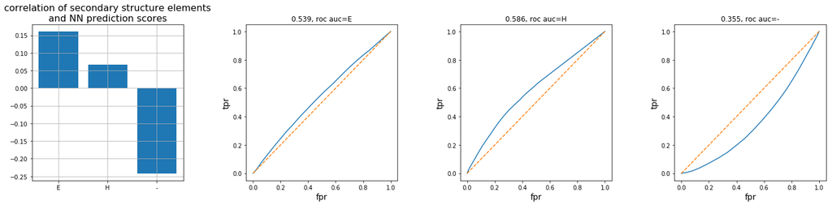

```python
# PLOT
plt.figure(figsize=(20,5))

# bar plot of correlations
plt.subplot(1,4,1)
plt.grid()
plt.bar(ss_psipred_set, r)
plt.title('correlation of secondary structure elements\nand NN prediction scores', fontsize=16);

# Roc curve with original class
from sklearn.metrics import roc_curve, auc, roc_auc_score

for n,element_i in enumerate(range(3)):
    fpr, tpr, thresholds = roc_curve(tads.values, rho[:,element_i])
    plt.subplot(1,4,n+2)
    plt.plot(fpr, tpr)
    plt.plot([0,1], [0,1], ls="--")
    plt.xlabel('fpr', fontsize=14)
    plt.ylabel('tpr', fontsize=14)
    plt.title('{:.3f}, roc auc={}'.format(roc_auc_score(tads.values, rho[:,element_i]), ss_psipred_set[element_i]))

plt.tight_layout();
```

```python
idx1 = np.where(data.TAD==1)[0]
idx0 = np.where(data.TAD==0)[0]

r1,r2=[],[]
for i in range(3):
    r1.append(spearmanr(preds[idx1], rho[idx1,i])[0])
    r2.append(spearmanr(preds[idx0], rho[idx0,i])[0])

print(ss_psipred_set)
print(r1)
print(r2)
```

```
['E', 'H', '-']
[0.2054747640604997, -0.19990335258091188, 0.04747566103220744]
[0.17360695741289164, -0.03243760010999594, -0.15484978606490013]
```

### 2. cluster samples on 2ry structure elements and then see correlation "ss vs TAD score" within clusters.

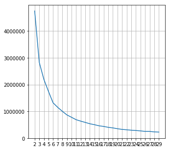

```python
from sklearn.cluster import KMeans, DBSCAN
from sklearn.decomposition import PCA

elbow=[]
for clusters in range(2,30):
    km = KMeans(n_clusters=clusters, random_state=8).fit(rho)
    elbow.append(km.inertia_)

plt.figure(figsize=(5,5))
plt.grid()
plt.xticks(range(2,30))
plt.plot(range(2,30), elbow)

km = KMeans(n_clusters=6, n_init=300, random_state=42).fit(rho)
_label = km.labels_

lrho = np.vstack([rho.T, _label, preds, tads]).T
```

Desicion based on the explained variance goes down is to split the data into 6 clusters.

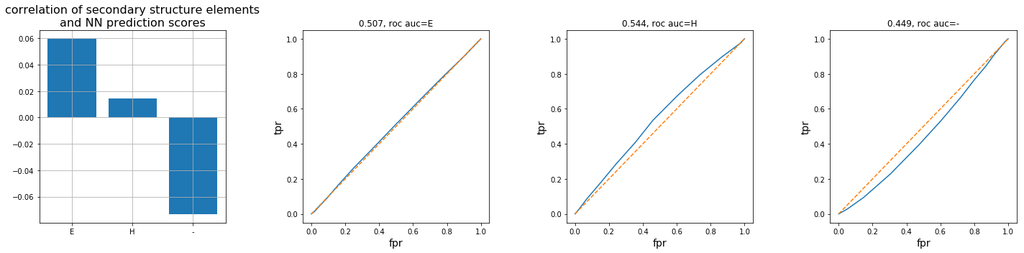

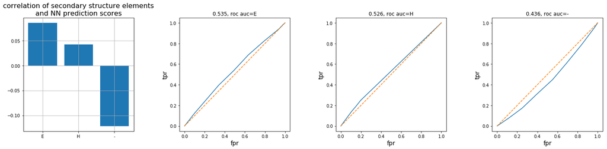

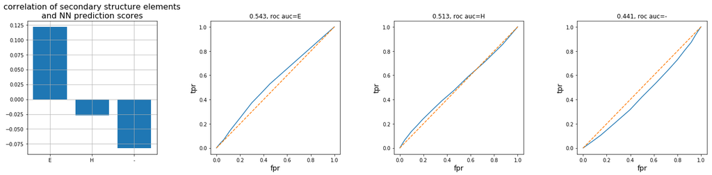

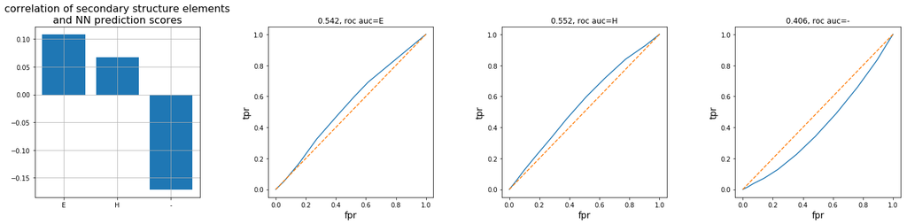

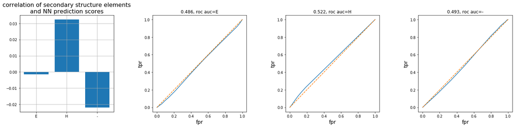

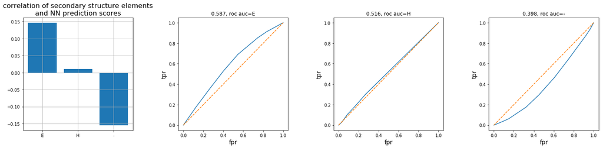

```python
for i in range(6):
    subset = lrho[lrho[:,3]==i]

    # calculate correlations
    r=[]
    for i in range(3):
        r.append(spearmanr(subset[:,4], subset[:,i])[0])


    # PLOT
    plt.figure(figsize=(20,5))

    # bar plot of correlations
    plt.subplot(1,4,1)
    plt.grid()
    plt.bar(ss_psipred_set, r)
    plt.title('correlation of secondary structure elements\nand NN prediction scores', fontsize=16);

    # Roc curve with original class
    from sklearn.metrics import roc_curve, auc, roc_auc_score

    for n,element_i in enumerate(range(3)):
        fpr, tpr, thresholds = roc_curve(subset[:,5], subset[:,element_i])
        plt.subplot(1,4,n+2)
        plt.plot(fpr, tpr)
        plt.plot([0,1], [0,1], ls="--")
        plt.xlabel('fpr', fontsize=14)
        plt.ylabel('tpr', fontsize=14)
        plt.title('{:.3f}, roc auc={}'.format(roc_auc_score(subset[:,5], subset[:,element_i]), ss_psipred_set[element_i]))

    plt.tight_layout()
```